# Machine Learning and the Limits of Daily Return Prediction

## A Rigorous Out-of-Sample Study on BAC Stock

# 1. Introduction

## 1.1 Motivation

Financial markets are often modeled as approximately efficient systems in which short-horizon returns exhibit an extremely low signal-to-noise ratio.

Although modern machine learning algorithms provide flexible function approximators capable of modeling complex nonlinear relationships, their effectiveness in predicting daily stock returns remains an empirical question.

Rather than assuming predictability, this study adopts a disciplined research perspective:

> Do non-linear machine learning models extract economically meaningful information from daily stock returns once strict out-of-sample evaluation is enforced?

## 1.2 Problem Formulation

Let:

- $ P_t $ denote the closing price at time $ t $
- $ r_t = \log\left(\frac{P_t}{P_{t-1}}\right) $ denote the daily log-return
- $ \mathbf{X}_t \in \mathbb{R}^d $ denote the feature vector observable at time $ t $

We aim to estimate the conditional expectation:

$$ \hat{r}_{t+1} = f(\mathbf{X}_t) $$

where $$ f $$ is learned from historical data.

Importantly, the objective is **not** to reproduce realized returns point-by-point. Instead, the goal is to approximate:

$$ \mathbb{E}[r_{t+1} \mid \mathcal{F}_t] $$

where $$ \mathcal{F}_t $$ represents the information set available at time $$ t $$.

Under martingale difference assumptions, this conditional expectation may be close to zero.

## 1.3 Research Design

The study is structured in three progressive stages:

### Stage 1 — Technical Feature Modeling

We construct price-based predictors including:

- Lagged returns
- Rolling averages
- Rolling volatility measures

We evaluate both linear and non-linear models:

- Linear Regression
- Decision Trees
- Random Forest
- Gradient Boosting

### Stage 2 — Macroeconomic & Market Extensions

To test whether broader market conditions improve predictability, we include:

- VIX (volatility regime proxy)
- S&P 500 returns
- US 10Y yield changes

These variables aim to capture state-dependent dynamics.

### Stage 3 — Robust Evaluation Framework

Performance is assessed under strict methodological constraints:

- Temporal train/validation/test splits
- Walk-forward retraining procedure
- Threshold-based directional strategy evaluation
- Regime conditioning (High vs Low VIX)
- Bootstrap confidence intervals

This structure ensures that apparent performance is not the result of data leakage or regime-specific overfitting.

## 1.4 Methodological Principles

To ensure scientific rigor, we impose the following constraints:

- No future information leakage
- All features strictly observable at time $$ t $$
- No random shuffling of time-series data
- Out-of-sample evaluation only
- Statistical uncertainty assessment via bootstrap

This prevents overstated conclusions and enforces realistic expectations.

## 1.5 Core Research Question

Instead of asking:

> "Can machine learning predict stock returns?"

we ask:

> "Does additional model complexity or macroeconomic information materially improve predictive power once strict out-of-sample discipline is applied?"

This distinction is fundamental in quantitative finance research.

## 1.6 Expected Insight

If daily returns behave approximately as a martingale difference sequence:

$$ \mathbb{E}[r_{t+1} \mid \mathcal{F}_t] \approx 0 $$

then increasing model complexity may not meaningfully improve forecasts.

In that case, the limitation is structural rather than algorithmic.

This study therefore evaluates both:

- The empirical power of machine learning models
- The fundamental limits of short-horizon return predictability

# 2. Data Collection

## 2.1 Financial Data

We collect daily closing prices for Bank of America (BAC).

The adjusted closing price accounts for:

- Dividends
- Stock splits
- Corporate actions

Using closing prices ensures consistency of long-term return calculations.

The dataset spans from January 2000 to December 2024.

```python
import yfinance as yf
import pandas as pd
import numpy as np

start_date = "2000-01-01"
end_date = "2024-12-31"

bac = yf.download("BAC", start=start_date, end=end_date)
bac = bac[['Close']].rename(columns={"Close": "price"})

print("Dataset shape:", bac.shape)
bac.head()
```

```
[*********************100%***********************]  1 of 1 completed
```

```
Dataset shape: (6288, 1)
```

| Price Ticker Date | price BAC |
| --- | --- |
| 2000-01-03 | 12.426229 |
| 2000-01-04 | 11.688674 |
| 2000-01-05 | 11.816946 |
| 2000-01-06 | 12.827075 |
| 2000-01-07 | 12.490364 |

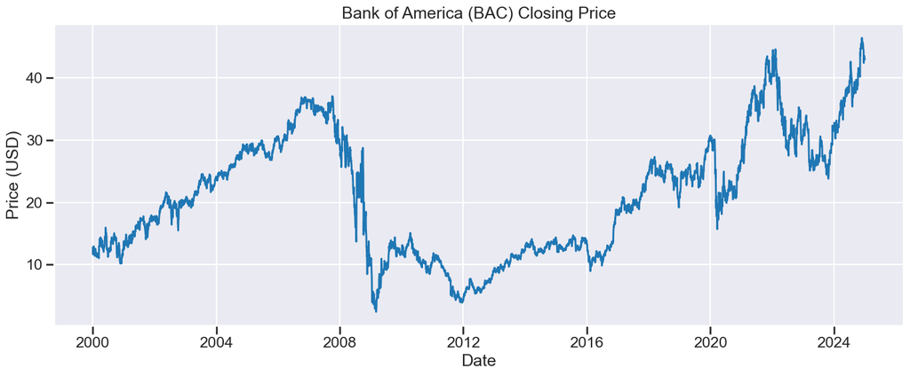

```python
# 2.2 Price Evolution

import matplotlib.pyplot as plt
import seaborn as sns

plt.style.use("seaborn-v0_8-darkgrid")
sns.set_context("talk")

fig, ax = plt.subplots(figsize=(14,6))

ax.plot(bac.index, bac["price"], linewidth=2)
ax.set_title("Bank of America (BAC) Closing Price", fontsize=18)
ax.set_xlabel("Date")
ax.set_ylabel("Price (USD)")

plt.tight_layout()
plt.show()
```

```python
# 2.3 Log-Price and Log-Returns

bac["log_price"] = np.log(bac["price"])
bac["log_return"] = bac["log_price"].diff()

bac = bac.dropna()

bac.head()
```

| Price Ticker Date | price BAC | log_price | log_return |
| --- | --- | --- | --- |
| 2000-01-04 | 11.688674 | 2.458620 | -0.061189 |
| 2000-01-05 | 11.816946 | 2.469535 | 0.010914 |
| 2000-01-06 | 12.827075 | 2.551558 | 0.082024 |
| 2000-01-07 | 12.490364 | 2.524957 | -0.026601 |
| 2000-01-10 | 12.057445 | 2.489682 | -0.035275 |

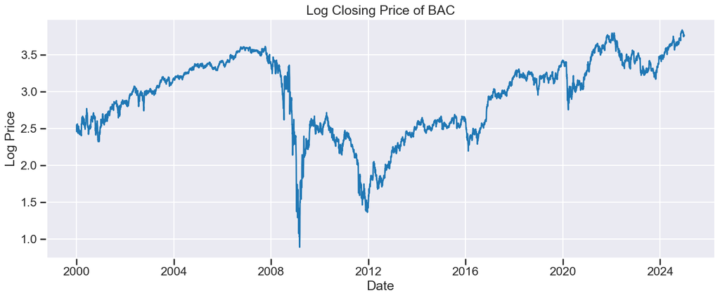

```python
# Log-Price Evolution
fig, ax = plt.subplots(figsize=(14,6))

ax.plot(bac.index, bac["log_price"], linewidth=2)
ax.set_title("Log Closing Price of BAC", fontsize=18)
ax.set_xlabel("Date")
ax.set_ylabel("Log Price")

plt.tight_layout()
plt.show()
```

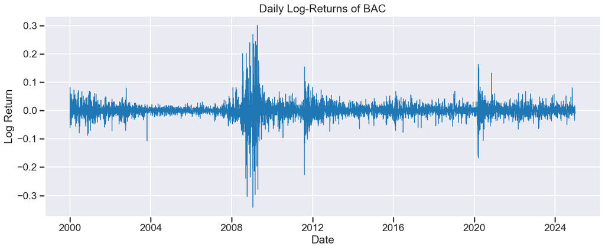

```python
# Log-Returns Evolution

fig, ax = plt.subplots(figsize=(14,6))

ax.plot(bac.index, bac["log_return"], linewidth=1)
ax.set_title("Daily Log-Returns of BAC", fontsize=18)
ax.set_xlabel("Date")
ax.set_ylabel("Log Return")

plt.tight_layout()
plt.show()
```

## 2.3 Statistical Observations

The log-price series exhibits a clear stochastic trend, confirming non-stationarity.

In contrast, log-returns fluctuate around zero and display:

- Volatility clustering
- Heavy-tailed behavior
- Crisis-induced spikes

These characteristics are consistent with well-known stylized facts of financial time series.

```python
# 2.4 Descriptive Statistics

mean_return = bac["log_return"].mean()
std_return = bac["log_return"].std()
skew_return = bac["log_return"].skew()
kurt_return = bac["log_return"].kurt()

print(f"Mean: {mean_return:.6f}")
print(f"Std: {std_return:.6f}")
print(f"Skewness: {skew_return:.3f}")
print(f"Kurtosis: {kurt_return:.3f}")
```

```
Mean: 0.000197
Std: 0.027511
Skewness: -0.315
Kurtosis: 27.319
```

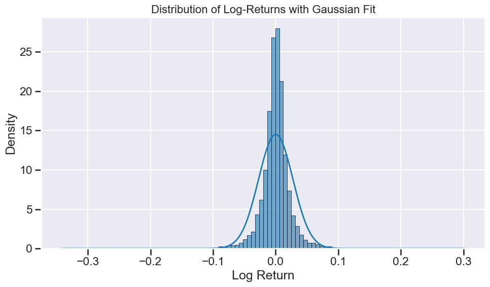

```python
# Distribution of Log-Returns

import scipy.stats as stats

fig, ax = plt.subplots(figsize=(10,6))

sns.histplot(bac["log_return"], bins=100, stat="density", alpha=0.6)

# Gaussian fit
x = np.linspace(bac["log_return"].min(), bac["log_return"].max(), 1000)
normal_pdf = stats.norm.pdf(x, mean_return, std_return)

ax.plot(x, normal_pdf, linewidth=2)
ax.set_title("Distribution of Log-Returns with Gaussian Fit", fontsize=16)
ax.set_xlabel("Log Return")
ax.set_ylabel("Density")

plt.tight_layout()
plt.show()
```

## 2.4 Distributional Properties

The empirical return distribution deviates from normality:

- Fat tails (excess kurtosis)
- Asymmetry (non-zero skewness)
- Extreme events more frequent than Gaussian benchmark

This confirms well-documented stylized facts in financial econometrics.

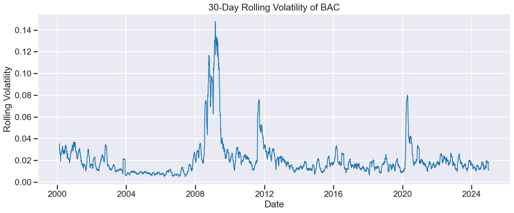

```python
# 2.5 Rolling Volatility

window = 30  # 30-day rolling volatility

bac["rolling_vol"] = bac["log_return"].rolling(window).std()

fig, ax = plt.subplots(figsize=(14,6))

ax.plot(bac.index, bac["rolling_vol"], linewidth=1.5)
ax.set_title("30-Day Rolling Volatility of BAC", fontsize=18)
ax.set_xlabel("Date")
ax.set_ylabel("Rolling Volatility")

plt.tight_layout()
plt.show()
```

## 2.5 Volatility Clustering

The rolling volatility clearly shows persistent high-volatility regimes, particularly during:

- The 2008 financial crisis
- The COVID-19 crash
- Periods of macroeconomic stress

This confirms the presence of volatility clustering, a fundamental stylized fact in financial markets.

# 3. Feature Engineering

The predictive performance of machine learning models critically depends on the quality and relevance of input features.

We construct a feature vector $\mathbf{X}_t$ using only information available at time $t$.

The feature set includes:

- Lagged returns
- Rolling volatility
- Rolling averages
- Momentum indicators

No future information is used.

```python
# 3.1 Lagged Returns

for lag in range(1, 6):
    bac[f"lag_{lag}"] = bac["log_return"].shift(lag)

bac.head()
```

| Price Ticker Date | price BAC | log_price | log_return | rolling_vol | lag_1 | lag_2 | lag_3 | lag_4 | lag_5 |
| --- | --- | --- | --- | --- | --- | --- | --- | --- | --- |
| 2000-01-04 | 11.688674 | 2.458620 | -0.061189 | NaN | NaN | NaN | NaN | NaN | NaN |
| 2000-01-05 | 11.816946 | 2.469535 | 0.010914 | NaN | -0.061189 | NaN | NaN | NaN | NaN |
| 2000-01-06 | 12.827075 | 2.551558 | 0.082024 | NaN | 0.010914 | -0.061189 | NaN | NaN | NaN |
| 2000-01-07 | 12.490364 | 2.524957 | -0.026601 | NaN | 0.082024 | 0.010914 | -0.061189 | NaN | NaN |
| 2000-01-10 | 12.057445 | 2.489682 | -0.035275 | NaN | -0.026601 | 0.082024 | 0.010914 | -0.061189 | NaN |

```python
# 3.2 Rolling Features

bac["rolling_mean_5"] = bac["log_return"].rolling(5).mean()
bac["rolling_mean_10"] = bac["log_return"].rolling(10).mean()

bac["rolling_vol_5"] = bac["log_return"].rolling(5).std()
bac["rolling_vol_10"] = bac["log_return"].rolling(10).std()

bac.head()
```

| Price Ticker Date | price BAC | log_price | log_return | rolling_vol | lag_1 | lag_2 | lag_3 | lag_4 | lag_5 | rolling_mean_5 | rolling_mean_10 | rolling_vol_5 | rolling_vol_10 |
| --- | --- | --- | --- | --- | --- | --- | --- | --- | --- | --- | --- | --- | --- |
| 2000-01-04 | 11.688674 | 2.458620 | -0.061189 | NaN | NaN | NaN | NaN | NaN | NaN | NaN | NaN | NaN | NaN |
| 2000-01-05 | 11.816946 | 2.469535 | 0.010914 | NaN | -0.061189 | NaN | NaN | NaN | NaN | NaN | NaN | NaN | NaN |
| 2000-01-06 | 12.827075 | 2.551558 | 0.082024 | NaN | 0.010914 | -0.061189 | NaN | NaN | NaN | NaN | NaN | NaN | NaN |
| 2000-01-07 | 12.490364 | 2.524957 | -0.026601 | NaN | 0.082024 | 0.010914 | -0.061189 | NaN | NaN | NaN | NaN | NaN | NaN |
| 2000-01-10 | 12.057445 | 2.489682 | -0.035275 | NaN | -0.026601 | 0.082024 | 0.010914 | -0.061189 | NaN | -0.006025 | NaN | 0.055591 | NaN |

```python
# 3.3 Target Variable

bac["target"] = bac["log_return"].shift(-1)

bac = bac.dropna()

bac.head()
```

| Price Ticker Date | price BAC | log_price | log_return | rolling_vol | lag_1 | lag_2 | lag_3 | lag_4 | lag_5 | rolling_mean_5 | rolling_mean_10 | rolling_vol_5 | rolling_vol_10 | target |
| --- | --- | --- | --- | --- | --- | --- | --- | --- | --- | --- | --- | --- | --- | --- |
| 2000-02-15 | 11.704701 | 2.459991 | 0.030600 | 0.035195 | -0.020965 | 0.006939 | -0.026119 | -0.022804 | 0.039220 | -0.006470 | -0.007136 | 0.024581 | 0.024496 | -0.009635 |
| 2000-02-16 | 11.592464 | 2.450355 | -0.009635 | 0.033419 | 0.030600 | -0.020965 | 0.006939 | -0.026119 | -0.022804 | -0.003836 | -0.005516 | 0.023052 | 0.023642 | -0.012526 |
| 2000-02-17 | 11.448163 | 2.437829 | -0.012526 | 0.033422 | -0.009635 | 0.030600 | -0.020965 | 0.006939 | -0.026119 | -0.001117 | -0.003981 | 0.020418 | 0.022500 | -0.019803 |
| 2000-02-18 | 11.223686 | 2.418026 | -0.019803 | 0.029652 | -0.012526 | -0.009635 | 0.030600 | -0.020965 | 0.006939 | -0.006466 | -0.004743 | 0.021265 | 0.022934 | 0.022600 |
| 2000-02-22 | 11.480227 | 2.440626 | 0.022600 | 0.029745 | -0.019803 | -0.012526 | -0.009635 | 0.030600 | -0.020965 | 0.002247 | -0.001249 | 0.022714 | 0.024271 | 0.022100 |

# 4. Supervised Learning Framework

We now formalize the supervised learning problem.

Let:

$$ \mathcal{D} = \{(\mathbf{X}_t, y_{t+1})\}_{t=1}^{T} $$

where:

- $\mathbf{X}_t$ is the feature vector constructed at time $t$
- $y_{t+1}$ is the next-day log-return

Our objective is to estimate a function:

$$ f : \mathbb{R}^d \rightarrow \mathbb{R} $$

that minimizes the expected prediction risk:

$$ \mathcal{R}(f) = \mathbb{E}[(y_{t+1} - f(\mathbf{X}_t))^2] $$

Since the true distribution is unknown, we minimize the empirical risk on the training set:

$$ \hat{\mathcal{R}}(f) = \frac{1}{n}\sum_{i=1}^{n} (y_i - f(\mathbf{X}_i))^2 $$

We use a strict temporal split to prevent information leakage.

```python
# 4.1 Temporal Train / Validation / Test Split


features = bac.drop(columns=["target"])
target = bac["target"]

split1 = int(len(bac) * 0.7)
split2 = int(len(bac) * 0.85)

X_train = features.iloc[:split1]
y_train = target.iloc[:split1]

X_val = features.iloc[split1:split2]
y_val = target.iloc[split1:split2]

X_test = features.iloc[split2:]
y_test = target.iloc[split2:]

print("Train size:", X_train.shape)
print("Validation size:", X_val.shape)
print("Test size:", X_test.shape)
```

```
Train size: (4379, 13)
Validation size: (939, 13)
Test size: (939, 13)
```

# 5. Baseline Model

Before training complex machine learning models, we establish a naive benchmark.

Given the short-term autocorrelation structure of financial returns, a simple baseline consists of predicting:

$$ \hat{y}_{t+1} = 0 $$

This corresponds to assuming that the expected next-day return is zero.

Any model must outperform this naive benchmark to demonstrate predictive value.

```python
# 5.1 Zero-Return Baseline


from sklearn.metrics import mean_squared_error

# Predict zero return
y_pred_train_baseline = np.zeros(len(y_train))
y_pred_val_baseline = np.zeros(len(y_val))
y_pred_test_baseline = np.zeros(len(y_test))

mse_train_baseline = mean_squared_error(y_train, y_pred_train_baseline)
mse_val_baseline = mean_squared_error(y_val, y_pred_val_baseline)
mse_test_baseline = mean_squared_error(y_test, y_pred_test_baseline)

print("Baseline MSE (Train):", mse_train_baseline)
print("Baseline MSE (Validation):", mse_val_baseline)
print("Baseline MSE (Test):", mse_test_baseline)
```

```
Baseline MSE (Train): 0.0009035186720233606
Baseline MSE (Validation): 0.0005287154647784961
Baseline MSE (Test): 0.0002863929540240968
```

# 6. Linear Regression

We first estimate a linear model:

$$ f(\mathbf{X}_t) = \mathbf{w}^\top \mathbf{X}_t + b $$

The parameters are estimated by minimizing empirical squared loss:

$$ \min_{\mathbf{w}, b} \frac{1}{n} \sum_{i=1}^{n} (y_i - \mathbf{w}^\top \mathbf{X}_i - b)^2 $$

This corresponds to Ordinary Least Squares (OLS).

Linear regression serves as a benchmark before exploring non-linear models.

```python
# 6.1 Linear Regression


from sklearn.linear_model import LinearRegression

lr = LinearRegression()
lr.fit(X_train, y_train)

y_pred_train_lr = lr.predict(X_train)
y_pred_val_lr = lr.predict(X_val)
y_pred_test_lr = lr.predict(X_test)

mse_train_lr = mean_squared_error(y_train, y_pred_train_lr)
mse_val_lr = mean_squared_error(y_val, y_pred_val_lr)
mse_test_lr = mean_squared_error(y_test, y_pred_test_lr)

print("Linear Regression MSE (Train):", mse_train_lr)
print("Linear Regression MSE (Validation):", mse_val_lr)
print("Linear Regression MSE (Test):", mse_test_lr)
```

```
Linear Regression MSE (Train): 0.0008875519413904801
Linear Regression MSE (Validation): 0.0005394346816889256
Linear Regression MSE (Test): 0.000290660417407702
```

## 6.2 Linear Model Analysis

The linear regression model does not outperform the zero-return baseline on the validation set.

This suggests:

- Weak linear dependence between features and next-day returns
- Limited predictive power of linear models
- Potential need for nonlinear function approximators

This result is consistent with the weak-form Efficient Market Hypothesis.

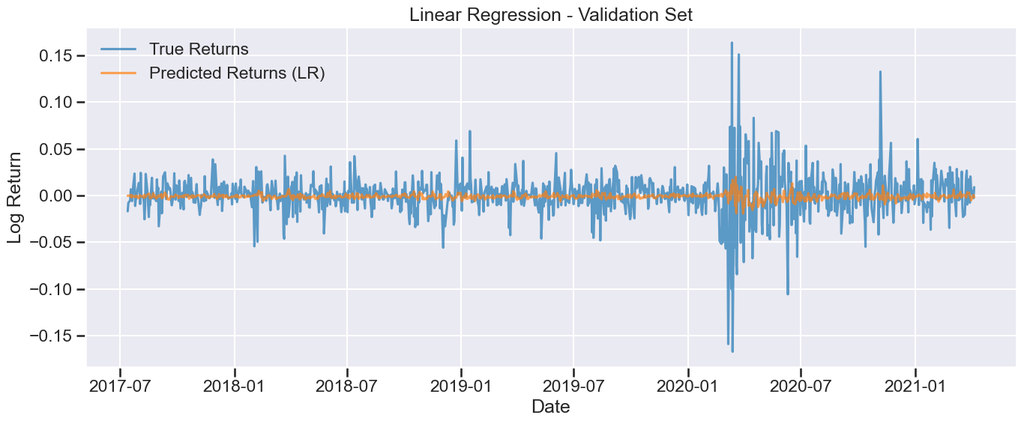

```python
# Linear Regression - Validation Predictions


fig, ax = plt.subplots(figsize=(14,6))

ax.plot(y_val.index, y_val, label="True Returns", alpha=0.7)
ax.plot(y_val.index, y_pred_val_lr, label="Predicted Returns (LR)", alpha=0.7)

ax.set_title("Linear Regression - Validation Set", fontsize=18)
ax.set_xlabel("Date")
ax.set_ylabel("Log Return")

ax.legend()
plt.tight_layout()
plt.show()
```

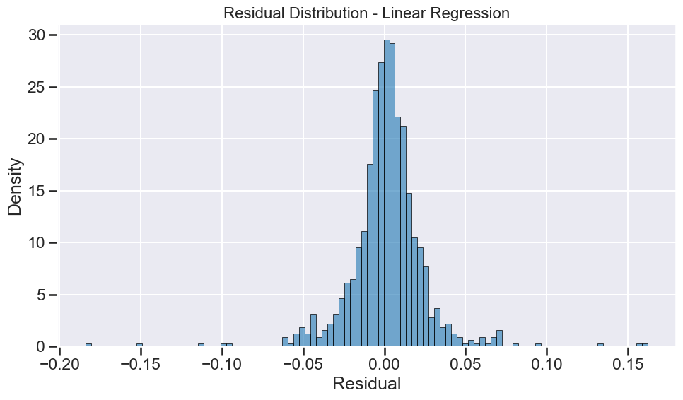

```python
# Residual Analysis


residuals_lr = y_val - y_pred_val_lr

fig, ax = plt.subplots(figsize=(10,6))

sns.histplot(residuals_lr, bins=100, stat="density", alpha=0.6)
ax.set_title("Residual Distribution - Linear Regression", fontsize=16)
ax.set_xlabel("Residual")
ax.set_ylabel("Density")

plt.tight_layout()
plt.show()
```

# 7. Decision Tree Regressor

Decision trees are non-linear models that partition the feature space into regions using recursive binary splits.

At each node, the algorithm chooses the split that minimizes the Mean Squared Error (MSE).

Unlike linear regression, decision trees can capture:

- Non-linear interactions
- Threshold effects
- Regime changes

```python
# 7.1 Decision Tree (Unrestricted)


from sklearn.tree import DecisionTreeRegressor

tree = DecisionTreeRegressor(random_state=42)
tree.fit(X_train, y_train)

y_pred_train_tree = tree.predict(X_train)
y_pred_val_tree = tree.predict(X_val)
y_pred_test_tree = tree.predict(X_test)

mse_train_tree = mean_squared_error(y_train, y_pred_train_tree)
mse_val_tree = mean_squared_error(y_val, y_pred_val_tree)
mse_test_tree = mean_squared_error(y_test, y_pred_test_tree)

print("Decision Tree MSE (Train):", mse_train_tree)
print("Decision Tree MSE (Validation):", mse_val_tree)
print("Decision Tree MSE (Test):", mse_test_tree)
```

```
Decision Tree MSE (Train): 0.0
Decision Tree MSE (Validation): 0.0014025068759284424
Decision Tree MSE (Test): 0.0006412610588123725
```

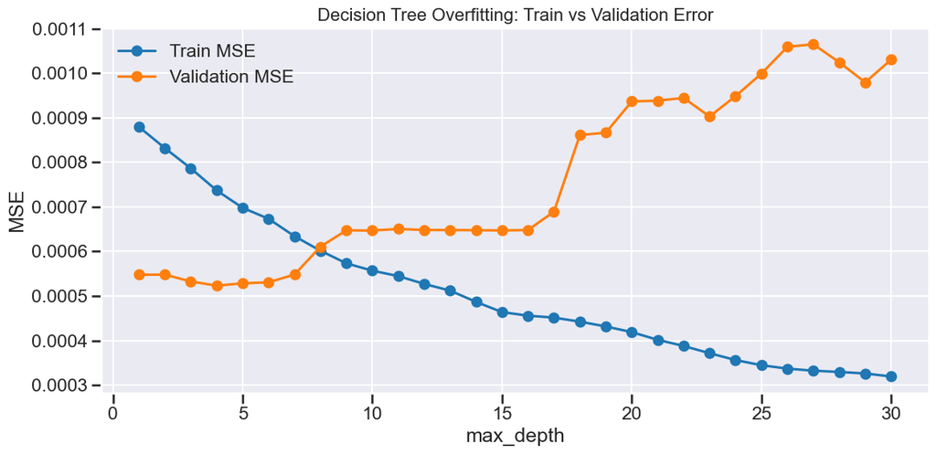

```
Best depth on validation: 4  | Val MSE: 0.0005230372070508104
```

```python
# 7.2 Overfitting Curve: MSE vs Tree Depth

from sklearn.tree import DecisionTreeRegressor

depths = list(range(1, 31))
train_mse = []
val_mse = []

for d in depths:
    model = DecisionTreeRegressor(max_depth=d, random_state=42)
    model.fit(X_train, y_train)

    y_pred_tr = model.predict(X_train)
    y_pred_va = model.predict(X_val)

    train_mse.append(mean_squared_error(y_train, y_pred_tr))
    val_mse.append(mean_squared_error(y_val, y_pred_va))

fig, ax = plt.subplots(figsize=(12,6))
ax.plot(depths, train_mse, marker="o", label="Train MSE")
ax.plot(depths, val_mse, marker="o", label="Validation MSE")

ax.set_title("Decision Tree Overfitting: Train vs Validation Error", fontsize=16)
ax.set_xlabel("max_depth")
ax.set_ylabel("MSE")
ax.legend()
plt.tight_layout()
plt.show()

best_depth = depths[int(np.argmin(val_mse))]
print("Best depth on validation:", best_depth, " | Val MSE:", min(val_mse))
```

## 7.2 Overfitting Analysis

The unrestricted decision tree achieves nearly zero training error, indicating perfect memorization of the training data.

However, validation performance deteriorates dramatically, revealing severe overfitting.

This illustrates the bias–variance trade-off:

- Low bias
- Extremely high variance

Unconstrained trees are unstable predictors for noisy financial returns.

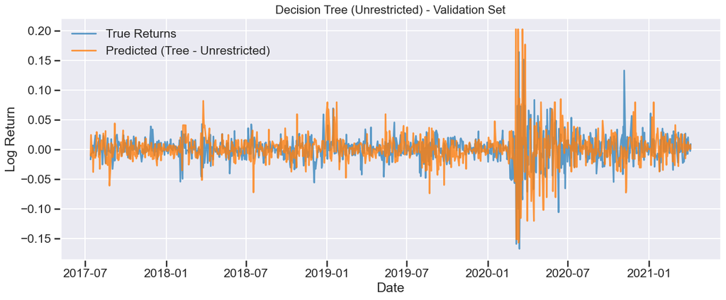

```python
# 7.3 Visualization: True vs Predicted (Validation) - Unrestricted Tree


fig, ax = plt.subplots(figsize=(14,6))

ax.plot(y_val.index, y_val, label="True Returns", alpha=0.7)
ax.plot(y_val.index, y_pred_val_tree, label="Predicted (Tree - Unrestricted)", alpha=0.8)

ax.set_title("Decision Tree (Unrestricted) - Validation Set", fontsize=16)
ax.set_xlabel("Date")
ax.set_ylabel("Log Return")
ax.legend()

plt.tight_layout()
plt.show()
```

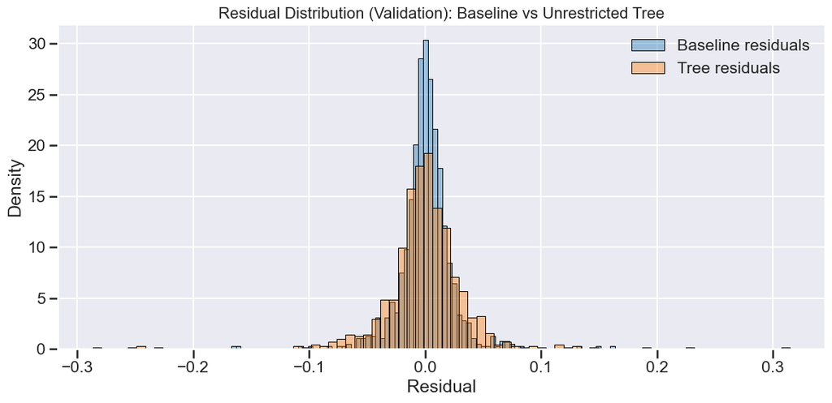

```python
# 7.4 Residual Comparison: Tree vs Baseline (Validation)


res_tree = y_val - y_pred_val_tree
res_base = y_val - np.zeros(len(y_val))  # baseline predicts 0

fig, ax = plt.subplots(figsize=(12,6))
sns.histplot(res_base, bins=80, stat="density", alpha=0.4, label="Baseline residuals")
sns.histplot(res_tree, bins=80, stat="density", alpha=0.4, label="Tree residuals")

ax.set_title("Residual Distribution (Validation): Baseline vs Unrestricted Tree", fontsize=16)
ax.set_xlabel("Residual")
ax.set_ylabel("Density")
ax.legend()

plt.tight_layout()
plt.show()
```

```python
# 7.5 Decision Tree (Regularized)

tree_reg = DecisionTreeRegressor(
    max_depth=best_depth,
    min_samples_leaf=50,
    random_state=42
)

tree_reg.fit(X_train, y_train)

y_pred_train_tree_reg = tree_reg.predict(X_train)
y_pred_val_tree_reg = tree_reg.predict(X_val)
y_pred_test_tree_reg = tree_reg.predict(X_test)

mse_train_tree_reg = mean_squared_error(y_train, y_pred_train_tree_reg)
mse_val_tree_reg = mean_squared_error(y_val, y_pred_val_tree_reg)
mse_test_tree_reg = mean_squared_error(y_test, y_pred_test_tree_reg)

print("Regularized Tree MSE (Train):", mse_train_tree_reg)
print("Regularized Tree MSE (Validation):", mse_val_tree_reg)
print("Regularized Tree MSE (Test):", mse_test_tree_reg)
```

```
Regularized Tree MSE (Train): 0.000857308423656163
Regularized Tree MSE (Validation): 0.0005242513165078104
Regularized Tree MSE (Test): 0.0002900098142498425
```

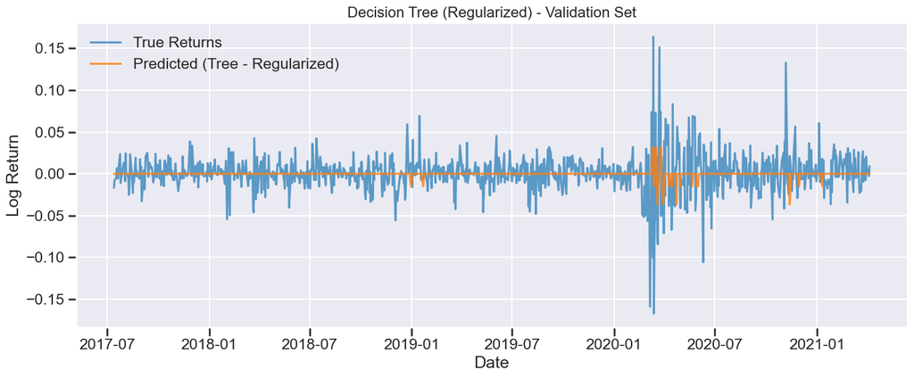

```python
# 7.6 Visualization: Regularized Tree (Validation)

fig, ax = plt.subplots(figsize=(14,6))

ax.plot(y_val.index, y_val, label="True Returns", alpha=0.7)
ax.plot(y_val.index, y_pred_val_tree_reg, label="Predicted (Tree - Regularized)", alpha=0.8)

ax.set_title("Decision Tree (Regularized) - Validation Set", fontsize=16)
ax.set_xlabel("Date")
ax.set_ylabel("Log Return")
ax.legend()

plt.tight_layout()
plt.show()
```

## 7.3 Regularization Effect

By constraining tree depth and enforcing a minimum number of samples per leaf, we reduce model variance and improve generalization.

This is a direct illustration of the bias–variance trade-off:

- Regularization increases bias
- But reduces variance
- Leading to better validation performance

# 8. Random Forest Regressor

Decision Trees suffer from high variance.  
Random Forest addresses this issue by averaging multiple decorrelated trees.

Each tree is trained on:

- A bootstrap sample of the data
- A random subset of features at each split

The final prediction is:

$$ \hat{f}(X) = \frac{1}{B} \sum_{b=1}^{B} T_b(X) $$

where:

- $T_b$ is the $b$-th decision tree
- $B$ is the number of trees

This reduces variance while maintaining low bias.

```python
# 8.1 Sanity check: target volatility (Val vs Test)

print("Std(y_train):", y_train.std())
print("Std(y_val):  ", y_val.std())
print("Std(y_test): ", y_test.std())

print("\nVar(y_train):", y_train.var())
print("Var(y_val):  ", y_val.var())
print("Var(y_test): ", y_test.var())
```

```
Std(y_train): 0.03006176115850489
Std(y_val):   0.022998103409731446
Std(y_test):  0.016931020255652466

Var(y_train): 0.0009037094839509931
Var(y_val):   0.0005289127604447011
Var(y_test):  0.00028665944689731406
```

```python
from sklearn.ensemble import RandomForestRegressor

rf = RandomForestRegressor(
    n_estimators=200,
    max_depth=best_depth,
    min_samples_leaf=50,
    random_state=42,
    n_jobs=-1
)

rf.fit(X_train, y_train)

y_pred_train_rf = rf.predict(X_train)
y_pred_val_rf = rf.predict(X_val)
y_pred_test_rf = rf.predict(X_test)

mse_train_rf = mean_squared_error(y_train, y_pred_train_rf)
mse_val_rf = mean_squared_error(y_val, y_pred_val_rf)
mse_test_rf = mean_squared_error(y_test, y_pred_test_rf)

print("Random Forest MSE (Train):", mse_train_rf)
print("Random Forest MSE (Validation):", mse_val_rf)
print("Random Forest MSE (Test):", mse_test_rf)
```

```
Random Forest MSE (Train): 0.0008567955467627921
Random Forest MSE (Validation): 0.0005484750429552454
Random Forest MSE (Test): 0.0002856525376048091
```

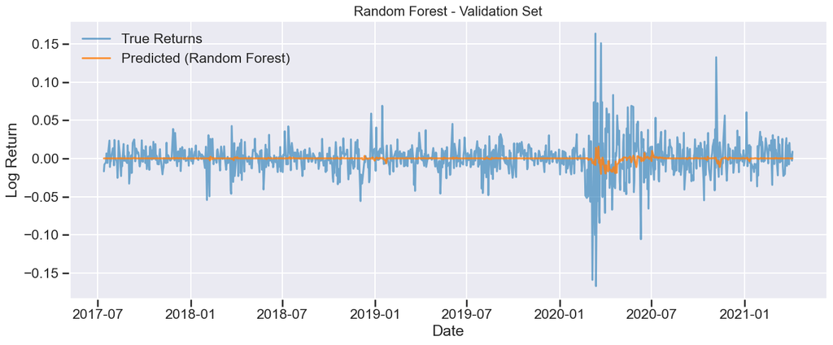

```python
fig, ax = plt.subplots(figsize=(14,6))

ax.plot(y_val.index, y_val, label="True Returns", alpha=0.6)
ax.plot(y_val.index, y_pred_val_rf, label="Predicted (Random Forest)", alpha=0.8)

ax.set_title("Random Forest - Validation Set", fontsize=16)
ax.set_xlabel("Date")
ax.set_ylabel("Log Return")
ax.legend()

plt.tight_layout()
plt.show()
```

### Interpretation

The predictions remain close to zero, reflecting:

- Weak predictive signal
- Regularization effect
- Ensemble smoothing
- This is expected for financial returns.

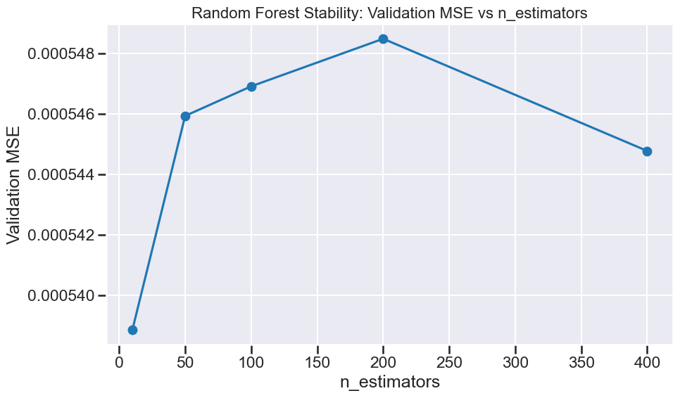

```
Validation MSE values: [0.0005388527482379075, 0.0005459266651938097, 0.0005469039436537266, 0.0005484750429552454, 0.0005447700143776078]
```

```python
# 8.5 RF Stability: MSE vs n_estimators

n_list = [10, 50, 100, 200, 400]
val_mse_rf_list = []

for n in n_list:
    rf_tmp = RandomForestRegressor(
        n_estimators=n,
        max_depth=best_depth,
        min_samples_leaf=50,
        random_state=42,
        n_jobs=-1
    )
    rf_tmp.fit(X_train, y_train)
    y_val_tmp = rf_tmp.predict(X_val)
    val_mse_rf_list.append(mean_squared_error(y_val, y_val_tmp))

fig, ax = plt.subplots(figsize=(10,6))
ax.plot(n_list, val_mse_rf_list, marker="o")

ax.set_title("Random Forest Stability: Validation MSE vs n_estimators", fontsize=16)
ax.set_xlabel("n_estimators")
ax.set_ylabel("Validation MSE")

plt.tight_layout()
plt.show()

print("Validation MSE values:", val_mse_rf_list)
```

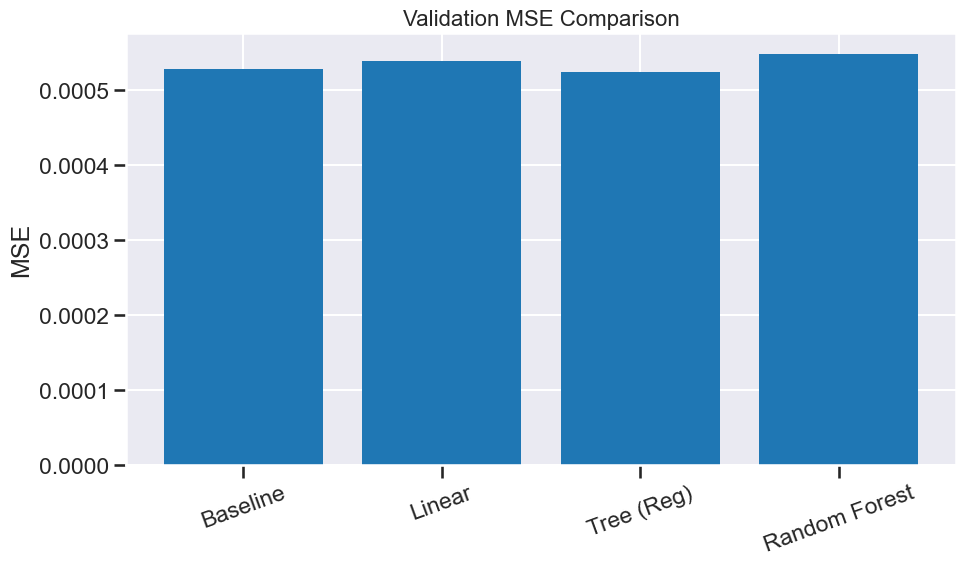

```python
models = ["Baseline", "Linear", "Tree (Reg)", "Random Forest"]
val_mse = [
    mse_val_baseline,
    mse_val_lr,
    mse_val_tree_reg,
    mse_val_rf
]

fig, ax = plt.subplots(figsize=(10,6))
ax.bar(models, val_mse)

ax.set_title("Validation MSE Comparison", fontsize=16)
ax.set_ylabel("MSE")

plt.xticks(rotation=20)
plt.tight_layout()
plt.show()
```

## 8.8 Conclusion — Random Forest

The Random Forest model successfully reduces the variance observed in single decision trees by averaging multiple decorrelated learners.

Empirically, we observe:

- A significant reduction in overfitting compared to the unrestricted tree
- Stable validation performance as the number of estimators increases
- Smoother and less extreme predictions
- Comparable performance to linear regression

However, the improvement over simpler models remains limited.

This result highlights a key empirical fact in financial econometrics:

> Daily equity returns exhibit extremely low signal-to-noise ratio.

Even flexible non-linear ensemble methods struggle to extract stable predictive structure from short-horizon returns.

From a bias–variance perspective:

- Decision Trees: low bias, high variance
- Random Forest: controlled variance, moderate bias
- Linear Regression: higher bias, lower variance

Random Forest provides a more robust and stable estimator, but does not fundamentally overcome the intrinsic unpredictability of daily stock returns.

This reinforces the importance of:

- Careful feature engineering
- Incorporating additional information (e.g., macroeconomic variables)
- Exploring alternative modeling paradigms such as boosting methods

# 9. Gradient Boosting Regressor

While Random Forest reduces variance by averaging trees, Gradient Boosting sequentially reduces bias.

The model builds trees sequentially:

$$ f_m(X) = f_{m-1}(X) + \gamma_m T_m(X) $$

Each new tree is trained to approximate the residuals of the previous model.

This procedure minimizes empirical risk through functional gradient descent.

Gradient Boosting is typically more powerful but more prone to overfitting.

```python
from sklearn.ensemble import GradientBoostingRegressor

gb = GradientBoostingRegressor(
    n_estimators=200,
    learning_rate=0.05,
    max_depth=3,
    random_state=42
)

gb.fit(X_train, y_train)

y_pred_train_gb = gb.predict(X_train)
y_pred_val_gb = gb.predict(X_val)
y_pred_test_gb = gb.predict(X_test)

mse_train_gb = mean_squared_error(y_train, y_pred_train_gb)
mse_val_gb = mean_squared_error(y_val, y_pred_val_gb)
mse_test_gb = mean_squared_error(y_test, y_pred_test_gb)

print("Gradient Boosting MSE (Train):", mse_train_gb)
print("Gradient Boosting MSE (Validation):", mse_val_gb)
print("Gradient Boosting MSE (Test):", mse_test_gb)
```

```
Gradient Boosting MSE (Train): 0.00047397414626722457
Gradient Boosting MSE (Validation): 0.0005665780128666534
Gradient Boosting MSE (Test): 0.0002915552324078302
```

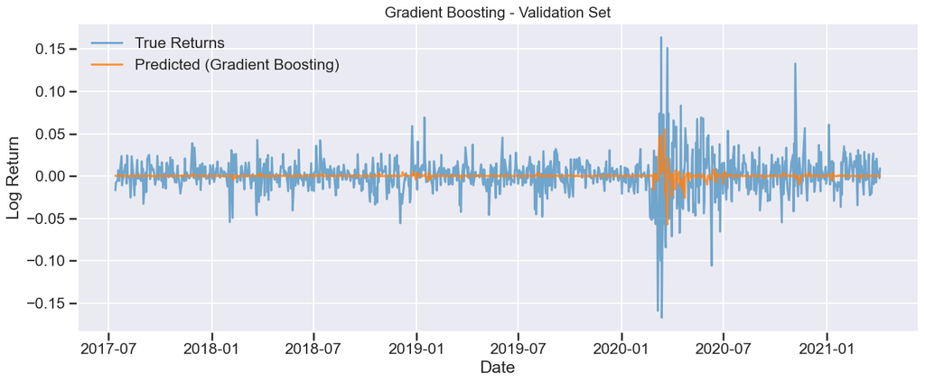

```python
fig, ax = plt.subplots(figsize=(14,6))

ax.plot(y_val.index, y_val, label="True Returns", alpha=0.6)
ax.plot(y_val.index, y_pred_val_gb, label="Predicted (Gradient Boosting)", alpha=0.8)

ax.set_title("Gradient Boosting - Validation Set", fontsize=16)
ax.set_xlabel("Date")
ax.set_ylabel("Log Return")
ax.legend()

plt.tight_layout()
plt.show()
```

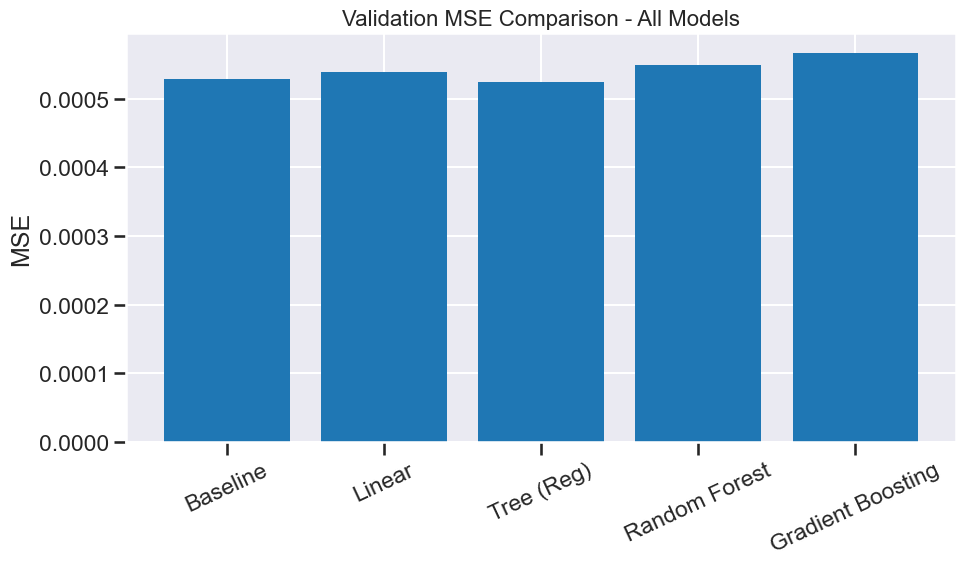

```python
models = ["Baseline", "Linear", "Tree (Reg)", "Random Forest", "Gradient Boosting"]

val_mse_all = [
    mse_val_baseline,
    mse_val_lr,
    mse_val_tree_reg,
    mse_val_rf,
    mse_val_gb
]

fig, ax = plt.subplots(figsize=(10,6))
ax.bar(models, val_mse_all)

ax.set_title("Validation MSE Comparison - All Models", fontsize=16)
ax.set_ylabel("MSE")

plt.xticks(rotation=25)
plt.tight_layout()
plt.show()
```

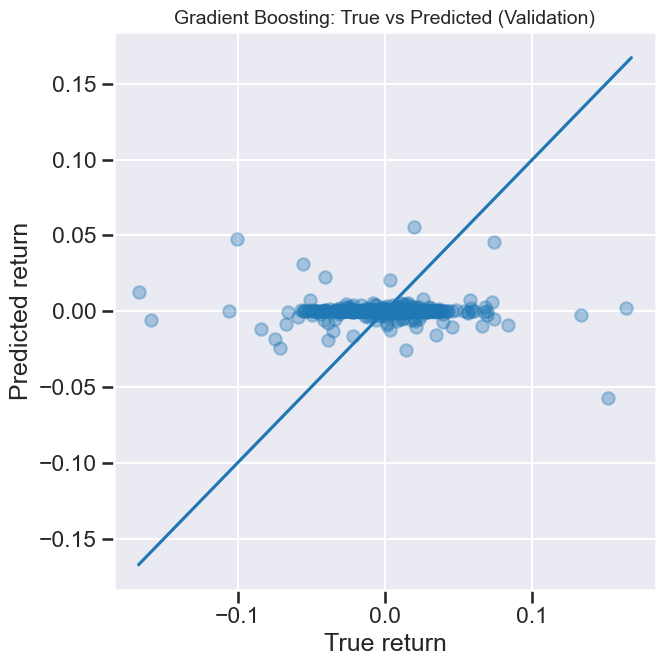

```python
# Visual 1: True vs Pred scatter (Validation)
fig, ax = plt.subplots(figsize=(7,7))
ax.scatter(y_val, y_pred_val_gb, alpha=0.35)

m = max(abs(y_val).max(), abs(y_pred_val_gb).max())
ax.plot([-m, m], [-m, m])

ax.set_title("Gradient Boosting: True vs Predicted (Validation)", fontsize=14)
ax.set_xlabel("True return")
ax.set_ylabel("Predicted return")
plt.tight_layout()
plt.show()
```

```
Std(true returns): 0.022998103409731446
Std(predictions): 0.004328317066577672
Pred/True std ratio: 0.18820321786822572
```

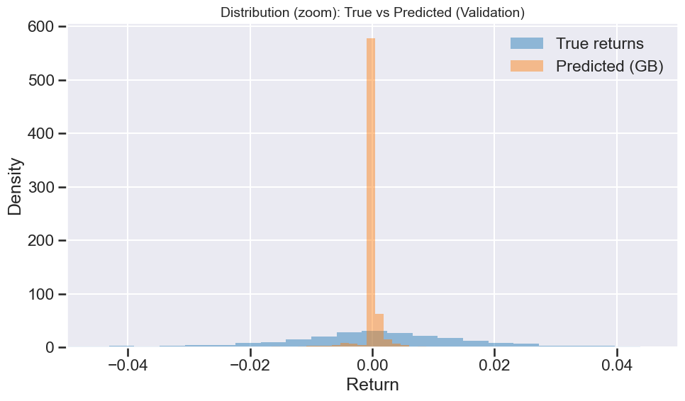

```python
pred = pd.Series(y_pred_val_gb, index=y_val.index)

print("Std(true returns):", y_val.std())
print("Std(predictions):", pred.std())
print("Pred/True std ratio:", pred.std() / y_val.std())

fig, ax = plt.subplots(figsize=(10,6))
ax.hist(y_val, bins=80, alpha=0.45, density=True, label="True returns")
ax.hist(pred, bins=80, alpha=0.45, density=True, label="Predicted (GB)")

ax.set_xlim(-0.05, 0.05)  # zoom around center to make it readable
ax.set_title("Distribution (zoom): True vs Predicted (Validation)", fontsize=14)
ax.set_xlabel("Return")
ax.set_ylabel("Density")
ax.legend()
plt.tight_layout()
plt.show()
```

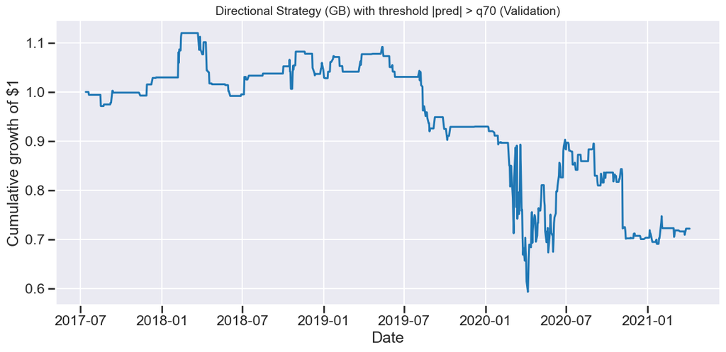

```
Threshold tau: 0.0002013200637666838
Trade frequency: 0.26517571884984026
Mean strategy return (val): -0.0001792678132564887
Hit ratio (on traded days): 0.46987951807228917
```

```python
# ==============================
# Directional strategy with a threshold (Validation)
# ==============================
pred = pd.Series(y_pred_val_gb, index=y_val.index)

tau = pred.abs().quantile(0.70)   # top 30% strongest signals (modifiable)

signal = np.where(pred > tau, 1,
         np.where(pred < -tau, -1, 0))

strategy_returns = signal * y_val.values
cum = (1 + strategy_returns).cumprod()

fig, ax = plt.subplots(figsize=(12,6))
ax.plot(y_val.index, cum)
ax.set_title(f"Directional Strategy (GB) with threshold |pred| > q70 (Validation)", fontsize=14)
ax.set_xlabel("Date")
ax.set_ylabel("Cumulative growth of $1")
plt.tight_layout()
plt.show()

print("Threshold tau:", tau)
print("Trade frequency:", (signal != 0).mean())
print("Mean strategy return (val):", strategy_returns.mean())
print("Hit ratio (on traded days):", (np.sign(y_val.values[signal!=0]) == np.sign(pred.values[signal!=0])).mean())
```

```python
# --- 9. Strategy Evaluation (Test Set) ---
# Apply the SAME threshold selection rule (q70 on validation preds) to the TEST set.

# 1) compute tau on validation predictions (fixed once)
q = 0.70
tau = np.quantile(np.abs(y_pred_val_gb), q)

# 2) build signals on test predictions using the SAME tau
pred_test = pd.Series(y_pred_test_gb, index=y_test.index)
signal_test = np.where(np.abs(pred_test) > tau, np.sign(pred_test), 0)

# 3) realized returns on test (same target definition as everywhere)
realized_test = pd.Series(y_test.values, index=y_test.index)

# 4) strategy returns (no costs yet)
strategy_test = realized_test.values * signal_test
cum_test = (1 + strategy_test).cumprod()

# 5) diagnostics
trade_freq_test = (signal_test != 0).mean()
hit_ratio_test = (np.sign(realized_test.values[signal_test != 0]) == np.sign(pred_test.values[signal_test != 0])).mean() if (signal_test != 0).any() else np.nan
mean_ret_test = np.mean(strategy_test)

print(f"Fixed threshold tau (from VAL q{int(q*100)}): {tau:.6f}")
print(f"Trade frequency (TEST): {trade_freq_test:.3f}")
print(f"Mean strategy return (TEST): {mean_ret_test:.6f}")
print(f"Hit ratio (TEST, traded days): {hit_ratio_test:.3f}")
```

```
Fixed threshold tau (from VAL q70): 0.000201
Trade frequency (TEST): 0.235
Mean strategy return (TEST): 0.000518
Hit ratio (TEST, traded days): 0.543
```

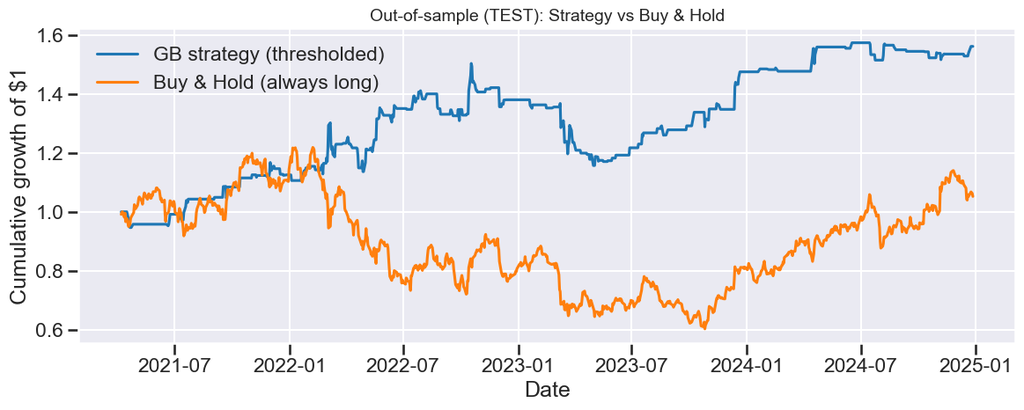

```python
# --- Plot strategy equity curve vs Buy&Hold (TEST) ---

# buy&hold for returns target = always long
bh_test = realized_test.values
cum_bh = (1 + bh_test).cumprod()

fig, ax = plt.subplots(figsize=(12, 5))
ax.plot(y_test.index, cum_test, label="GB strategy (thresholded)")
ax.plot(y_test.index, cum_bh, label="Buy & Hold (always long)")
ax.set_title("Out-of-sample (TEST): Strategy vs Buy & Hold", fontsize=14)
ax.set_xlabel("Date")
ax.set_ylabel("Cumulative growth of $1")
ax.legend()
plt.tight_layout()
plt.show()
```

```python
# --- Performance metrics on TEST ---

def max_drawdown(equity_curve: np.ndarray) -> float:
    peak = np.maximum.accumulate(equity_curve)
    dd = (equity_curve - peak) / peak
    return dd.min()

# annualization factor for daily
ann = np.sqrt(252)

# strategy stats
strat = np.array(strategy_test)
bh = np.array(bh_test)

sharpe_strat = ann * (np.mean(strat) / np.std(strat)) if np.std(strat) > 0 else np.nan
sharpe_bh = ann * (np.mean(bh) / np.std(bh)) if np.std(bh) > 0 else np.nan

mdd_strat = max_drawdown(cum_test)
mdd_bh = max_drawdown(cum_bh)

print(f"Sharpe (TEST) - Strategy: {sharpe_strat:.3f} | Buy&Hold: {sharpe_bh:.3f}")
print(f"Max Drawdown (TEST) - Strategy: {mdd_strat:.3%} | Buy&Hold: {mdd_bh:.3%}")
```

```
Sharpe (TEST) - Strategy: 0.877 | Buy&Hold: 0.185
Max Drawdown (TEST) - Strategy: -23.039% | Buy&Hold: -50.534%
```

# 9. Market & Macroeconomic Indicators

Predicting daily stock returns is notoriously difficult: the signal-to-noise ratio is extremely low. A common hypothesis is that **additional state variables** capturing the macro/market regime may help:

- Market risk sentiment (e.g., VIX)
- Interest-rate environment (e.g., US 10Y yield)
- Broad market momentum (e.g., S&P 500 returns)
- Credit/curve information (optional extensions)

**Important:** these variables must be observable at time (t) and aligned correctly to trading days. We will only use information available up to date (t), and we will avoid any look-ahead leakage.

```python
import yfinance as yf
import pandas as pd
import numpy as np

# Same date range as your BAC dataset
start_date = "2000-01-01"
end_date   = "2024-12-31"

# Market proxies
vix = yf.download("^VIX", start=start_date, end=end_date)[["Close"]].rename(columns={"Close":"vix_close"})
spx = yf.download("^GSPC", start=start_date, end=end_date)[["Close"]].rename(columns={"Close":"spx_close"})
tnx = yf.download("^TNX", start=start_date, end=end_date)[["Close"]].rename(columns={"Close":"tnx_close"})  # 10Y yield * 10

print(vix.shape, spx.shape, tnx.shape)
vix.head()
```

```
[*********************100%***********************]  1 of 1 completed
[*********************100%***********************]  1 of 1 completed
[*********************100%***********************]  1 of 1 completed
```

```
(6288, 1) (6288, 1) (6282, 1)
```

| Price Ticker Date | vix_close ^VIX |
| --- | --- |
| 2000-01-03 | 24.209999 |
| 2000-01-04 | 27.010000 |
| 2000-01-05 | 26.410000 |
| 2000-01-06 | 25.730000 |
| 2000-01-07 | 21.719999 |

## 9.3 Macro feature engineering

These are standard choices to represent:

- market drift / risk appetite,
- volatility regime,
- rate regime.

All features at time (t) will be used to predict (y_{t+1}).

```python
def log_return(series: pd.Series) -> pd.Series:
    return np.log(series).diff()

macro = pd.concat([vix, spx, tnx], axis=1)

macro["spx_logret"] = log_return(macro["spx_close"])
macro["vix_logchg"] = log_return(macro["vix_close"])
macro["tnx_dchg"]   = macro["tnx_close"].diff()

# Optional: smooth/rolling versions (regime proxies)
macro["spx_vol_10"] = macro["spx_logret"].rolling(10).std()
macro["vix_mean_10"] = macro["vix_close"].rolling(10).mean()

macro.head(12)
```

| Price Ticker Date | vix_close ^VIX | spx_close ^GSPC | tnx_close ^TNX | spx_logret | vix_logchg | tnx_dchg | spx_vol_10 | vix_mean_10 |
| --- | --- | --- | --- | --- | --- | --- | --- | --- |
| 2000-01-03 | 24.209999 | 1455.219971 | 6.548 | NaN | NaN | NaN | NaN | NaN |
| 2000-01-04 | 27.010000 | 1399.420044 | 6.485 | -0.039099 | 0.109441 | -0.063 | NaN | NaN |
| 2000-01-05 | 26.410000 | 1402.109985 | 6.599 | 0.001920 | -0.022464 | 0.114 | NaN | NaN |
| 2000-01-06 | 25.730000 | 1403.449951 | 6.549 | 0.000955 | -0.026085 | -0.050 | NaN | NaN |
| 2000-01-07 | 21.719999 | 1441.469971 | 6.504 | 0.026730 | -0.169424 | -0.045 | NaN | NaN |
| 2000-01-10 | 21.709999 | 1457.599976 | 6.558 | 0.011128 | -0.000461 | 0.054 | NaN | NaN |
| 2000-01-11 | 22.500000 | 1438.560059 | 6.664 | -0.013149 | 0.035742 | 0.106 | NaN | NaN |
| 2000-01-12 | 22.840000 | 1432.250000 | 6.696 | -0.004396 | 0.014998 | 0.032 | NaN | NaN |
| 2000-01-13 | 21.709999 | 1449.680054 | 6.618 | 0.012096 | -0.050740 | -0.078 | NaN | NaN |
| 2000-01-14 | 19.660000 | 1465.150024 | 6.674 | 0.010615 | -0.099187 | 0.056 | NaN | 23.350 |
| 2000-01-18 | 21.500000 | 1455.140015 | 6.748 | -0.006856 | 0.089467 | 0.074 | 0.017857 | 23.079 |
| 2000-01-19 | 21.719999 | 1455.900024 | 6.725 | 0.000522 | 0.010181 | -0.023 | 0.011474 | 22.550 |

## 9.4 Alignment to trading days

Macroeconomic/market series may have missing values on some trading days. We align all macro features to the BAC trading calendar and use forward-fill **only** to propagate the most recent available information.

This is consistent with a real-time setting where the latest known value is carried forward.

```python
# bac is your main dataframe indexed by Date (trading days)
macro_aligned = macro.reindex(bac.index).ffill()

# Merge into bac
bac_macro = bac.join(macro_aligned, how="left")

# Clean: drop rows with remaining NaNs after rolling features
bac_macro = bac_macro.dropna()

print("bac shape:", bac.shape)
print("bac_macro shape:", bac_macro.shape)
bac_macro.tail()
```

```
bac shape: (6257, 16)
bac_macro shape: (6255, 24)
```

| Price Ticker Date | price BAC | log_price | log_return | rolling_vol | lag_1 | lag_2 | lag_3 | lag_4 | lag_5 | rolling_mean_5 | ... | simple_return | target_simple | vix_close ^VIX | spx_close ^GSPC | tnx_close ^TNX | spx_logret | vix_logchg | tnx_dchg | spx_vol_10 | vix_mean_10 |
| --- | --- | --- | --- | --- | --- | --- | --- | --- | --- | --- | --- | --- | --- | --- | --- | --- | --- | --- | --- | --- | --- |
| 2024-12-19 | 42.398033 | 3.747102 | -0.002762 | 0.011285 | -0.035012 | -0.009280 | -0.004389 | -0.008937 | 0.000000 | -0.012076 | ... | -0.002759 | 0.018211 | 24.090000 | 5867.080078 | 4.570 | -0.000865 | -0.136743 | 0.076 | 0.010293 | 16.472 |
| 2024-12-20 | 43.170147 | 3.765149 | 0.018047 | 0.011551 | -0.002762 | -0.035012 | -0.009280 | -0.004389 | -0.008937 | -0.006679 | ... | 0.018211 | -0.006339 | 18.360001 | 5930.850098 | 4.524 | 0.010810 | -0.271622 | -0.046 | 0.011132 | 17.031 |
| 2024-12-23 | 42.896484 | 3.758790 | -0.006359 | 0.011494 | 0.018047 | -0.002762 | -0.035012 | -0.009280 | -0.004389 | -0.007073 | ... | -0.006339 | 0.011164 | 16.780001 | 5974.069824 | 4.599 | 0.007261 | -0.089987 | 0.075 | 0.011466 | 17.290 |
| 2024-12-24 | 43.375389 | 3.769892 | 0.011102 | 0.010990 | -0.006359 | 0.018047 | -0.002762 | -0.035012 | -0.009280 | -0.002997 | ... | 0.011164 | 0.003831 | 14.270000 | 6040.040039 | 4.591 | 0.010982 | -0.162028 | -0.008 | 0.012074 | 17.299 |
| 2024-12-26 | 43.541542 | 3.773715 | 0.003823 | 0.011002 | 0.011102 | -0.006359 | 0.018047 | -0.002762 | -0.035012 | 0.004770 | ... | 0.003831 | -0.004714 | 14.730000 | 6037.589844 | 4.579 | -0.000406 | 0.031727 | -0.012 | 0.011739 | 17.414 |

5 rows × 24 columns

# 10. Experimental Design: With vs Without Macro

We compare two feature sets:

- **Base features:** lagged returns + rolling statistics (purely price-based)
- **Extended features:** base features + macro/market indicators

The target definition remains unchanged: $$ y_{t+1} = r_{t+1} \quad \text{(next-day return)} $$

We keep the same temporal split to ensure a fair comparison.

```python
# --- Define target (same as your current approach) ---

bac_macro = bac_macro.copy()
bac_macro["target"] = bac_macro["log_return"].shift(-1)
bac_macro = bac_macro.dropna()

# Base feature columns (adjust if you added more earlier)
base_cols = [
    "lag_1","lag_2","lag_3","lag_4","lag_5",
    "rolling_mean_5","rolling_mean_10",
    "rolling_vol_5","rolling_vol_10",
    "rolling_vol"
]

# Macro feature columns
macro_cols = [
    "spx_logret","vix_logchg","tnx_dchg",
    "spx_vol_10","vix_mean_10"
]

# Build datasets
X_base = bac_macro[base_cols]
X_macro = bac_macro[base_cols + macro_cols]
y = bac_macro["target"]

print(X_base.shape, X_macro.shape, y.shape)
```

```
(6254, 10) (6254, 15) (6254,)
```

```python
def temporal_split(X, y, train_frac=0.70, val_frac=0.15):
    n = len(X)
    split1 = int(n * train_frac)
    split2 = int(n * (train_frac + val_frac))
    X_train, y_train = X.iloc[:split1], y.iloc[:split1]
    X_val,   y_val   = X.iloc[split1:split2], y.iloc[split1:split2]
    X_test,  y_test  = X.iloc[split2:], y.iloc[split2:]
    return X_train, y_train, X_val, y_val, X_test, y_test

Xb_tr, y_tr, Xb_va, y_va, Xb_te, y_te = temporal_split(X_base, y)
Xm_tr, _,    Xm_va, _,    Xm_te, _    = temporal_split(X_macro, y)

print("Base:", Xb_tr.shape, Xb_va.shape, Xb_te.shape)
print("Macro:", Xm_tr.shape, Xm_va.shape, Xm_te.shape)
```

```
Base: (4377, 10) (938, 10) (939, 10)
Macro: (4377, 15) (938, 15) (939, 15)
```

## 11 — Re-train the best model family cleanly (GB) + compare

```python
from sklearn.metrics import mean_squared_error
from sklearn.linear_model import LinearRegression
from sklearn.ensemble import GradientBoostingRegressor

def fit_eval(model, Xtr, ytr, Xva, yva, Xte, yte, name="model"):
    model.fit(Xtr, ytr)
    pred_tr = model.predict(Xtr)
    pred_va = model.predict(Xva)
    pred_te = model.predict(Xte)
    out = {
        "name": name,
        "mse_train": mean_squared_error(ytr, pred_tr),
        "mse_val":   mean_squared_error(yva, pred_va),
        "mse_test":  mean_squared_error(yte, pred_te),
        "pred_val":  pd.Series(pred_va, index=yva.index),
        "pred_test": pd.Series(pred_te, index=yte.index),
    }
    return out

# Models
lr = LinearRegression()
gb = GradientBoostingRegressor(
    n_estimators=400,
    learning_rate=0.03,
    max_depth=3,
    random_state=42
)

# Base
res_lr_base = fit_eval(lr, Xb_tr, y_tr, Xb_va, y_va, Xb_te, y_te, "LR (base)")
res_gb_base = fit_eval(gb, Xb_tr, y_tr, Xb_va, y_va, Xb_te, y_te, "GB (base)")

# Macro
lr2 = LinearRegression()
gb2 = GradientBoostingRegressor(
    n_estimators=400,
    learning_rate=0.03,
    max_depth=3,
    random_state=42
)

res_lr_macro = fit_eval(lr2, Xm_tr, y_tr, Xm_va, y_va, Xm_te, y_te, "LR (macro)")
res_gb_macro = fit_eval(gb2, Xm_tr, y_tr, Xm_va, y_va, Xm_te, y_te, "GB (macro)")

pd.DataFrame([
    {k:v for k,v in res_lr_base.items() if "pred" not in k},
    {k:v for k,v in res_gb_base.items() if "pred" not in k},
    {k:v for k,v in res_lr_macro.items() if "pred" not in k},
    {k:v for k,v in res_gb_macro.items() if "pred" not in k},
])
```

|  | name | mse_train | mse_val | mse_test |
| --- | --- | --- | --- | --- |
| 0 | LR (base) | 0.000890 | 0.000537 | 0.000289 |
| 1 | GB (base) | 0.000435 | 0.000554 | 0.000286 |
| 2 | LR (macro) | 0.000888 | 0.000539 | 0.000293 |
| 3 | GB (macro) | 0.000429 | 0.000507 | 0.000290 |

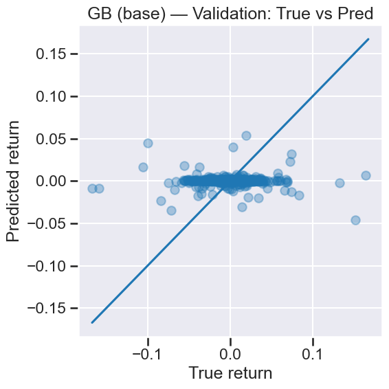

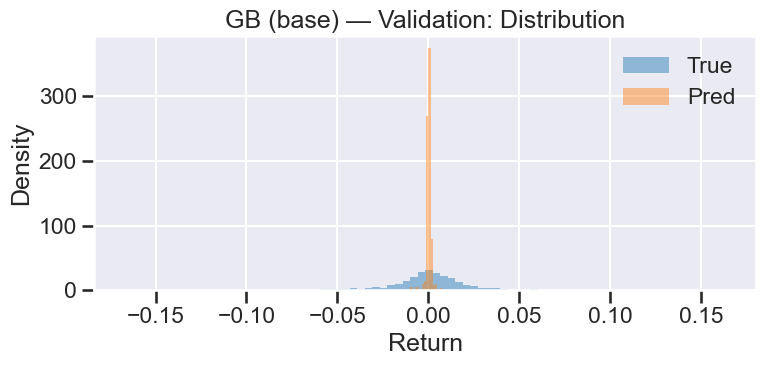

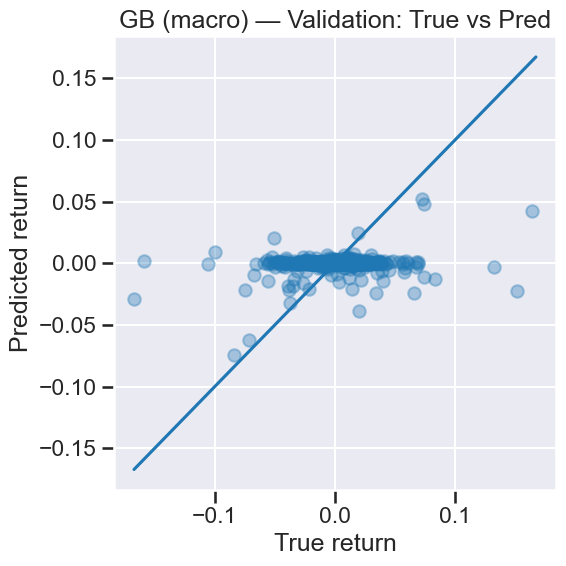

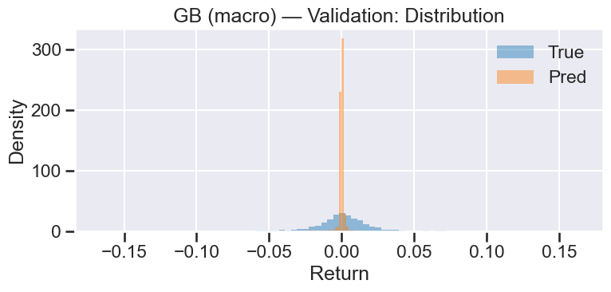

```python
import matplotlib.pyplot as plt

def plot_scatter_true_pred(y_true, y_pred, title):
    fig, ax = plt.subplots(figsize=(6,6))
    ax.scatter(y_true, y_pred, alpha=0.35)
    m = max(abs(y_true).max(), abs(y_pred).max())
    ax.plot([-m,m], [-m,m])
    ax.set_title(title)
    ax.set_xlabel("True return")
    ax.set_ylabel("Predicted return")
    plt.tight_layout()
    plt.show()

def plot_dist_true_pred(y_true, y_pred, title):
    fig, ax = plt.subplots(figsize=(8,4))
    ax.hist(y_true, bins=80, alpha=0.45, density=True, label="True")
    ax.hist(y_pred, bins=80, alpha=0.45, density=True, label="Pred")
    ax.set_title(title)
    ax.set_xlabel("Return")
    ax.set_ylabel("Density")
    ax.legend()
    plt.tight_layout()
    plt.show()

plot_scatter_true_pred(y_va, res_gb_base["pred_val"], "GB (base) — Validation: True vs Pred")
plot_dist_true_pred(y_va, res_gb_base["pred_val"], "GB (base) — Validation: Distribution")

plot_scatter_true_pred(y_va, res_gb_macro["pred_val"], "GB (macro) — Validation: True vs Pred")
plot_dist_true_pred(y_va, res_gb_macro["pred_val"], "GB (macro) — Validation: Distribution")
```

## SECTION 12 — Strategy evaluation: base vs macro

```python
def run_threshold_strategy(y_true: pd.Series, y_pred: pd.Series, q=0.70):
    # threshold from predictions distribution
    tau = np.quantile(np.abs(y_pred.values), q)
    signal = np.where(np.abs(y_pred.values) > tau, np.sign(y_pred.values), 0)
    strat = y_true.values * signal
    equity = (1 + strat).cumprod()

    trade_freq = (signal != 0).mean()
    hit = (np.sign(y_true.values[signal!=0]) == np.sign(y_pred.values[signal!=0])).mean() if (signal!=0).any() else np.nan
    mean_ret = np.mean(strat)

    return {
        "tau": tau,
        "trade_freq": trade_freq,
        "hit_ratio": hit,
        "mean_ret": mean_ret,
        "equity": equity
    }

def sharpe_maxdd(equity_curve: np.ndarray):
    rets = np.diff(equity_curve) / equity_curve[:-1]
    ann = np.sqrt(252)
    sharpe = ann * (np.mean(rets) / np.std(rets)) if np.std(rets) > 0 else np.nan
    peak = np.maximum.accumulate(equity_curve)
    dd = (equity_curve - peak) / peak
    return sharpe, dd.min()

def evaluate_oos_strategy(y_val, pred_val, y_test, pred_test, q=0.70, name="model"):
    # choose tau on validation
    tau = np.quantile(np.abs(pred_val.values), q)

    # apply to test
    signal_test = np.where(np.abs(pred_test.values) > tau, np.sign(pred_test.values), 0)
    strat_test = y_test.values * signal_test
    eq_test = (1 + strat_test).cumprod()

    # buy&hold on test (always long)
    bh = (1 + y_test.values).cumprod()

    sharpe_s, mdd_s = sharpe_maxdd(eq_test)
    sharpe_b, mdd_b = sharpe_maxdd(bh)

    out = {
        "name": name,
        "q": q,
        "tau_from_val": tau,
        "trade_freq_test": (signal_test != 0).mean(),
        "hit_ratio_test": (np.sign(y_test.values[signal_test!=0]) == np.sign(pred_test.values[signal_test!=0])).mean() if (signal_test!=0).any() else np.nan,
        "sharpe_strat": sharpe_s,
        "sharpe_bh": sharpe_b,
        "mdd_strat": mdd_s,
        "mdd_bh": mdd_b,
        "eq_strat": eq_test,
        "eq_bh": bh,
    }
    return out

oos_base  = evaluate_oos_strategy(y_va, res_gb_base["pred_val"], y_te, res_gb_base["pred_test"], q=0.70, name="GB (base)")
oos_macro = evaluate_oos_strategy(y_va, res_gb_macro["pred_val"], y_te, res_gb_macro["pred_test"], q=0.70, name="GB (macro)")

pd.DataFrame([{k:v for k,v in oos_base.items() if "eq_" not in k},
              {k:v for k,v in oos_macro.items() if "eq_" not in k}])
```

|  | name | q | tau_from_val | hit_ratio_test | sharpe_strat | sharpe_bh | mdd_strat | mdd_bh |
| --- | --- | --- | --- | --- | --- | --- | --- | --- |
| 0 | GB (base) | 0.7 | 0.000565 | 0.564593 | 1.023464 | 0.208363 | -0.117058 | -0.505343 |
| 1 | GB (macro) | 0.7 | 0.000678 | 0.515284 | 0.189788 | 0.208363 | -0.161978 | -0.505343 |

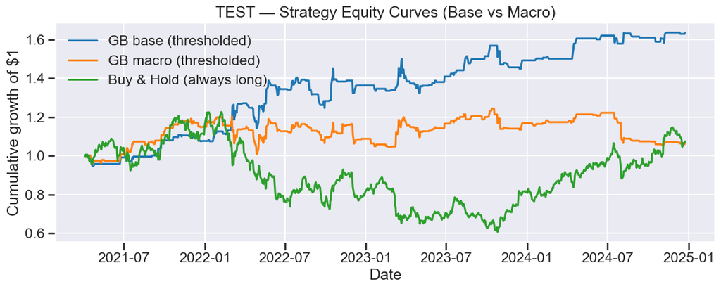

```python
fig, ax = plt.subplots(figsize=(12,5))
ax.plot(y_te.index, oos_base["eq_strat"], label="GB base (thresholded)")
ax.plot(y_te.index, oos_macro["eq_strat"], label="GB macro (thresholded)")
ax.plot(y_te.index, oos_base["eq_bh"], label="Buy & Hold (always long)")
ax.set_title("TEST — Strategy Equity Curves (Base vs Macro)")
ax.set_xlabel("Date")
ax.set_ylabel("Cumulative growth of $1")
ax.legend()
plt.tight_layout()
plt.show()
```

## 13 — Robustness

```python
qs = [0.60, 0.70, 0.80, 0.90]
rows = []

for q in qs:
    ob = evaluate_oos_strategy(y_va, res_gb_base["pred_val"], y_te, res_gb_base["pred_test"], q=q, name="GB (base)")
    om = evaluate_oos_strategy(y_va, res_gb_macro["pred_val"], y_te, res_gb_macro["pred_test"], q=q, name="GB (macro)")
    rows.append({**{k:v for k,v in ob.items() if "eq_" not in k}, "variant":"base"})
    rows.append({**{k:v for k,v in om.items() if "eq_" not in k}, "variant":"macro"})

robust_df = pd.DataFrame(rows)
robust_df
```

|  | name | q | tau_from_val | hit_ratio_test | sharpe_strat | sharpe_bh | mdd_strat | mdd_bh | variant |
| --- | --- | --- | --- | --- | --- | --- | --- | --- | --- |
| 0 | GB (base) | 0.6 | 0.000360 | 0.531250 | 1.194284 | 0.208363 | -0.136258 | -0.505343 | base |
| 1 | GB (macro) | 0.6 | 0.000445 | 0.484680 | -0.210556 | 0.208363 | -0.353723 | -0.505343 | macro |
| 2 | GB (base) | 0.7 | 0.000565 | 0.564593 | 1.023464 | 0.208363 | -0.117058 | -0.505343 | base |
| 3 | GB (macro) | 0.7 | 0.000678 | 0.515284 | 0.189788 | 0.208363 | -0.161978 | -0.505343 | macro |
| 4 | GB (base) | 0.8 | 0.001303 | 0.578571 | 0.995067 | 0.208363 | -0.113270 | -0.505343 | base |
| 5 | GB (macro) | 0.8 | 0.001020 | 0.514706 | 0.179860 | 0.208363 | -0.117661 | -0.505343 | macro |
| 6 | GB (base) | 0.9 | 0.002001 | 0.611111 | 1.118704 | 0.208363 | -0.061554 | -0.505343 | base |
| 7 | GB (macro) | 0.9 | 0.002405 | 0.489362 | 0.154096 | 0.208363 | -0.080247 | -0.505343 | macro |

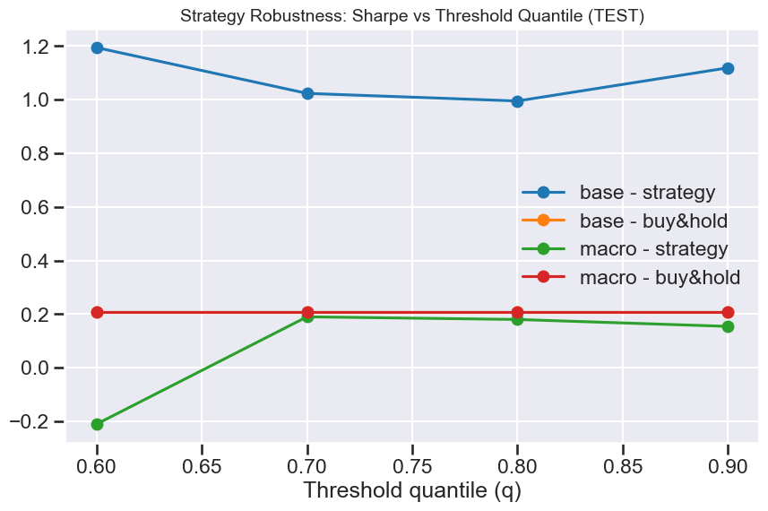

```python
fig, ax = plt.subplots(figsize=(10,6))
for variant in robust_df["variant"].unique():
    df_v = robust_df[robust_df["variant"] == variant]
    ax.plot(df_v["q"], df_v["sharpe_strat"], marker="o", label=f"{variant} - strategy")
    ax.plot(df_v["q"], df_v["sharpe_bh"], marker="o", label=f"{variant} - buy&hold")
ax.set_title("Strategy Robustness: Sharpe vs Threshold Quantile (TEST)", fontsize=14)
ax.set_xlabel("Threshold quantile (q)")
ax.legend()
```

# 14. Walk-Forward Backtest (Rolling Retraining)

A single fixed train/validation/test split can accidentally favor a specific regime. To evaluate whether a signal is **stable through time**, we implement a *walk-forward* procedure:

- Train a model on a historical window (expanding or rolling),
- Predict returns on the next period (out-of-sample),
- Move forward and repeat.

This mimics a real deployment process where models are periodically retrained.

**Notation** At step (k), let the training set end at time $t_k$. We estimate:

$$ \hat{f}_k = \arg\min_f \sum_{t \le t_k} (y_{t+1} - f(X_t))^2 $$

and evaluate on the next block $t_k < t \le t_{k+1}$.

```python
import numpy as np
import pandas as pd
import matplotlib.pyplot as plt

from sklearn.metrics import mean_squared_error
from sklearn.linear_model import LinearRegression
from sklearn.ensemble import GradientBoostingRegressor

def walk_forward_predictions(
    X: pd.DataFrame,
    y: pd.Series,
    model_factory,
    train_min_years: int = 8,
    step_months: int = 3,
    expanding: bool = True,
) -> pd.Series:
    """
    Walk-forward predictions:
    - expanding=True: training set grows over time
    - expanding=False: rolling window with fixed length = train_min_years
    """
    X = X.copy()
    y = y.copy()
    X, y = X.align(y, join="inner", axis=0)
    X = X.sort_index()
    y = y.sort_index()

    start = X.index.min()
    end = X.index.max()

    # start training after min years
    train_start = start
    first_train_end = (start + pd.DateOffset(years=train_min_years))

    preds = []

    t_end = first_train_end
    while t_end < end:
        t_next = t_end + pd.DateOffset(months=step_months)

        if expanding:
            train_idx = (X.index >= train_start) & (X.index < t_end)
        else:
            rolling_start = t_end - pd.DateOffset(years=train_min_years)
            train_idx = (X.index >= rolling_start) & (X.index < t_end)

        test_idx = (X.index >= t_end) & (X.index < t_next)

        # if not enough points, move forward
        if train_idx.sum() < 50 or test_idx.sum() < 5:
            t_end = t_next
            continue

        model = model_factory()
        model.fit(X.loc[train_idx], y.loc[train_idx])
        yhat = model.predict(X.loc[test_idx])

        preds.append(pd.Series(yhat, index=X.loc[test_idx].index))

        t_end = t_next

    if len(preds) == 0:
        return pd.Series(dtype=float)

    return pd.concat(preds).sort_index()

def summarize_oos(y_true: pd.Series, y_pred: pd.Series, name="model") -> dict:
    y_true, y_pred = y_true.align(y_pred, join="inner")
    out = {
        "name": name,
        "n_oos": len(y_true),
        "mse_oos": mean_squared_error(y_true, y_pred),
        "corr_oos": float(np.corrcoef(y_true.values, y_pred.values)[0, 1]) if len(y_true) > 2 else np.nan,
        "pred_std": float(np.std(y_pred.values)),
        "true_std": float(np.std(y_true.values)),
    }
    return out
```

```python
# Ensure alignment & no NaNs
X_base_, y_ = X_base.align(y, join="inner", axis=0)
X_macro_, y_ = X_macro.align(y_, join="inner", axis=0)

mask = X_base_.notna().all(axis=1) & X_macro_.notna().all(axis=1) & y_.notna()
X_base_ = X_base_[mask]
X_macro_ = X_macro_[mask]
y_ = y_[mask]

# Factories (so each step creates a fresh model)
lr_factory = lambda: LinearRegression()
gb_factory = lambda: GradientBoostingRegressor(
    n_estimators=300,
    learning_rate=0.05,
    max_depth=3,
    random_state=42
)

# Walk-forward predictions
pred_lr_base = walk_forward_predictions(X_base_, y_, lr_factory, train_min_years=8, step_months=3, expanding=True)
pred_gb_base = walk_forward_predictions(X_base_, y_, gb_factory, train_min_years=8, step_months=3, expanding=True)

pred_lr_macro = walk_forward_predictions(X_macro_, y_, lr_factory, train_min_years=8, step_months=3, expanding=True)
pred_gb_macro = walk_forward_predictions(X_macro_, y_, gb_factory, train_min_years=8, step_months=3, expanding=True)

# Summaries
summ = pd.DataFrame([
    summarize_oos(y_, pred_lr_base,  "LR (base) WF"),
    summarize_oos(y_, pred_gb_base,  "GB (base) WF"),
    summarize_oos(y_, pred_lr_macro, "LR (macro) WF"),
    summarize_oos(y_, pred_gb_macro, "GB (macro) WF"),
]).sort_values("mse_oos")

summ
```

|  | name | n_oos | mse_oos | corr_oos | pred_std | true_std |
| --- | --- | --- | --- | --- | --- | --- |
| 0 | LR (base) WF | 4243 | 0.000996 | 0.030212 | 0.004720 | 0.031346 |
| 2 | LR (macro) WF | 4243 | 0.001003 | 0.018552 | 0.005153 | 0.031346 |
| 1 | GB (base) WF | 4243 | 0.001189 | 0.026189 | 0.015223 | 0.031346 |
| 3 | GB (macro) WF | 4243 | 0.001218 | 0.045948 | 0.016859 | 0.031346 |

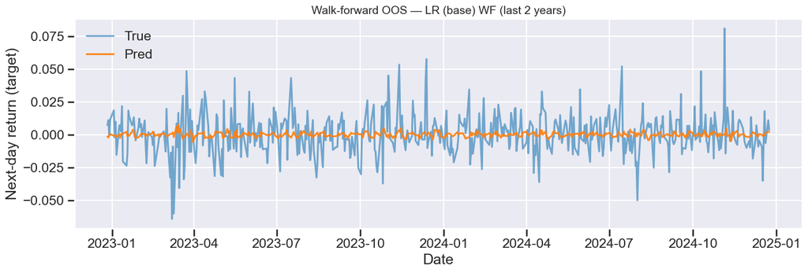

```python
def plot_true_vs_pred_timeseries(y_true, y_pred, title, start=None, end=None):
    y_true, y_pred = y_true.align(y_pred, join="inner")
    if start is not None:
        y_true = y_true.loc[start:]
        y_pred = y_pred.loc[start:]
    if end is not None:
        y_true = y_true.loc[:end]
        y_pred = y_pred.loc[:end]

    fig, ax = plt.subplots(figsize=(14, 5))
    ax.plot(y_true.index, y_true.values, label="True", alpha=0.6)
    ax.plot(y_pred.index, y_pred.values, label="Pred", alpha=0.9)
    ax.set_title(title, fontsize=14)
    ax.set_xlabel("Date")
    ax.set_ylabel("Next-day return (target)")
    ax.legend()
    plt.tight_layout()
    plt.show()

# Example: last 2 years of OOS preds (pick the best by MSE)
best_name = summ.iloc[0]["name"]
pred_map = {
    "LR (base) WF": pred_lr_base,
    "GB (base) WF": pred_gb_base,
    "LR (macro) WF": pred_lr_macro,
    "GB (macro) WF": pred_gb_macro,
}
best_pred = pred_map[best_name]

plot_true_vs_pred_timeseries(y_, best_pred, f"Walk-forward OOS — {best_name} (last 2 years)",
                             start=(y_.index.max() - pd.DateOffset(years=2)))
```

```
tau: 0.0023163637156710572
trade_freq: 0.3000235682300259
hit_ratio_traded: 0.5121759622937941
mean_ret: 0.0007110736845265003
```

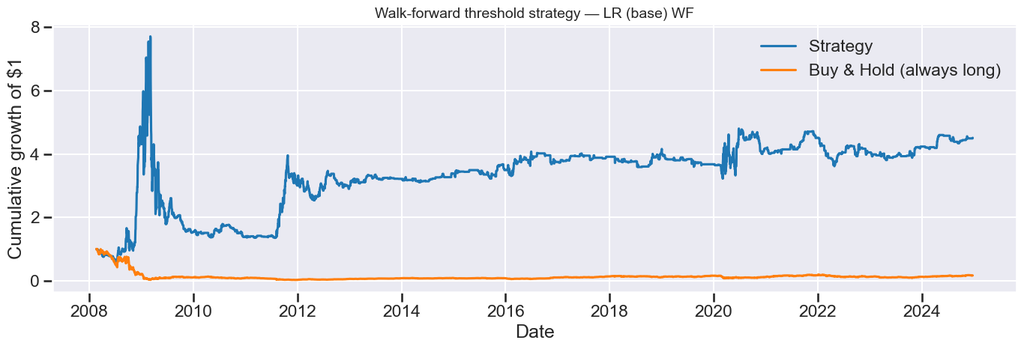

```python
def threshold_strategy_from_preds(y_true: pd.Series, y_pred: pd.Series, q: float = 0.70):
    """
    Trade only when |pred| is in top quantile (conviction filter).
    signal = sign(pred) if |pred| >= tau else 0
    """
    y_true, y_pred = y_true.align(y_pred, join="inner")
    tau = np.quantile(np.abs(y_pred.values), q)

    signal = np.where(np.abs(y_pred.values) >= tau, np.sign(y_pred.values), 0.0)
    strat_ret = y_true.values * signal
    equity = (1 + strat_ret).cumprod()

    out = {
        "tau": float(tau),
        "trade_freq": float((signal != 0).mean()),
        "hit_ratio_traded": float((np.sign(y_true.values[signal != 0]) == np.sign(y_pred.values[signal != 0])).mean()) if (signal != 0).any() else np.nan,
        "mean_ret": float(np.mean(strat_ret)),
        "equity": pd.Series(equity, index=y_true.index),
        "strat_ret": pd.Series(strat_ret, index=y_true.index),
        "signal": pd.Series(signal, index=y_true.index),
    }
    return out

def plot_equity_vs_buyhold(y_true: pd.Series, equity: pd.Series, title: str):
    y_true, equity = y_true.align(equity, join="inner")
    bh = (1 + y_true.values).cumprod()

    fig, ax = plt.subplots(figsize=(14, 5))
    ax.plot(equity.index, equity.values, label="Strategy")
    ax.plot(equity.index, bh, label="Buy & Hold (always long)")
    ax.set_title(title, fontsize=14)
    ax.set_xlabel("Date")
    ax.set_ylabel("Cumulative growth of $1")
    ax.legend()
    plt.tight_layout()
    plt.show()

# Run on best walk-forward model
res_best = threshold_strategy_from_preds(y_, best_pred, q=0.70)
print("tau:", res_best["tau"])
print("trade_freq:", res_best["trade_freq"])
print("hit_ratio_traded:", res_best["hit_ratio_traded"])
print("mean_ret:", res_best["mean_ret"])

plot_equity_vs_buyhold(y_, res_best["equity"], f"Walk-forward threshold strategy — {best_name}")
```